# Log-Scale Plots

*(with Matthias Zuckschwert)*

The purpose of this notebook is to visualize the advantages of log-scale plots.

Import packages necessary packages [matplotlib](https://matplotlib.org/) and yfinance.

```python
import matplotlib
from matplotlib import pyplot as plt
import yfinance as yf
print('matplotlib version: ' + matplotlib.__version__)
print('yfinance version: ' + yf.__version__)
```

```
matplotlib version: 3.5.0
yfinance version: 0.1.64
```

Download stock prices from yahoo finance.

```python
df = yf.download('AAPL', start='2000-01-01', end='2020-12-31')['Adj Close']
```

```
[*********************100%***********************]  1 of 1 completed
```

Let's make a straight-forward plot for the downloaded stock prices.

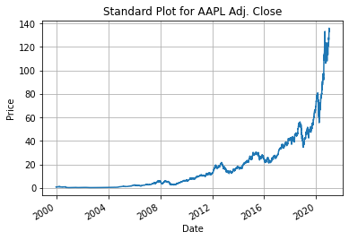

```python
# Standard Plot
df.plot()
plt.grid()
plt.title('Standard Plot for AAPL Adj. Close')
plt.ylabel('Price')
plt.xlabel('Date')
```

In this chart, the price changes from 2000 to 2008 are almost invisible, while the price changes from 2016 to 2020 seem much more extreme. This problem arises from the scale of the y-axis. A price change from 1 to 2 (100% price increase) looks the same as a price change from 100 to 101 (1% price increase). Therefore, small percentage changes at the end of the time series result in high absolute value changes.

To solve this problem, which mainly occurs when displaying time series over a longer period of time, the logarithmic scale is used for the y-axis. With the logarithmic scale, the distance from 1 to 10 is the same as for 10 to 100, so changes by the same factor always have the same distance.

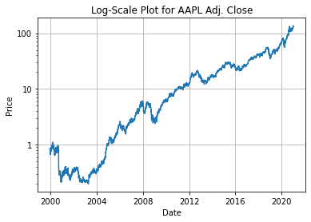

```python
# Log-scale Plot
fig1, ax1 = plt.subplots()
ax1.plot(df)
ax1.set_yscale('log') # scales the y-axis to log-scale
ax1.get_yaxis().set_major_formatter(matplotlib.ticker.ScalarFormatter()) # uses integers instead of 10^0, 10^1, 10^2,... as y-tickers
ax1.grid()
ax1.set_title('Log-Scale Plot for AAPL Adj. Close')
ax1.set_ylabel('Price')
ax1.set_xlabel('Date')
```

In this case, the log-scale plot is the much more appropriate visualization. Price changes by the same factor have the same distance on the y-axis. This also allows to recognize crises within this longer time horizon, like the burst of the dot-com bubble in 2000 or the financial crises in 2008/09, which were not visible in the standard plot.

Conclusion: Use log-scales to illustrate the long-term performance of an asset or a portfolio.